# ML week4

Deepthi Shivram

9/15/2018

## Introduction

### Using devices such as Jawbone Up, Nike FuelBand, and Fitbit it is now possible to collect a large amount of data about personal activity relatively inexpensively. These type of devices are part of the quantified self movement – a group of enthusiasts who take measurements about themselves regularly to improve their health, to find patterns in their behavior, or because they are tech geeks. One thing that people regularly do is quantify how much of a particular activity they do, but they rarely quantify how well they do it. In this project, your goal will be to use data from accelerometers on the belt, forearm, arm, and dumbell of 6 participants.

## Cleaning the Data

Remove all columns that contains NA and remove features that are not in the testing dataset. The features containing NA are the variance, mean and standard devition (SD) within each window for each feature. Since the testing dataset has no time-dependence, these values are useless and can be disregarded. We will also remove the first 7 features since they are related to the time-series or are not numeric

```r
clnColumnIndex <- colSums(is.na(training))/nrow(training) < 0.95
clean_training_data <- training[,clnColumnIndex]
clean_training_data <- clean_training_data[,-c(1:7)]
clean_test_data <- testing[,-c(1:7)]
```

## Dataset partition

```r
set.seed(12345)

inTrainIndex <- createDataPartition(clean_training_data$classe, p=0.75)[[1]]
training_training_data <- clean_training_data[inTrainIndex,]
training_crossval_data <- clean_training_data[-inTrainIndex,]
allNames <- names(clean_training_data)
clean_test_data <- testing[,allNames[1:52]]
```

## decision tree

Using Decision Tree, we shouldn’t expect the accuracy to be high. In fact, anything around 80% would be acceptable.

```r
decisionTreeMod <- train(classe ~., method='rpart', data=training_training_data)
decisionTreePrediction <- predict(decisionTreeMod, training_crossval_data)
confusionMatrix(training_crossval_data$classe, decisionTreePrediction)
```

```
## Confusion Matrix and Statistics
##
##           Reference
## Prediction   A   B   C   D   E
##          A 870 159 273  88   5
##          B 162 530 214  43   0
##          C  29  36 674 116   0
##          D  46 136 429 193   0
##          E  16 221 224  51 389
##
## Overall Statistics
##
##                Accuracy : 0.5416
##                  95% CI : (0.5275, 0.5556)
##     No Information Rate : 0.3699
##     P-Value [Acc > NIR] : < 2.2e-16
##
##                   Kappa : 0.4245
##  Mcnemar's Test P-Value : < 2.2e-16
##
## Statistics by Class:
##
##                      Class: A Class: B Class: C Class: D Class: E
## Sensitivity            0.7747   0.4898   0.3716  0.39308  0.98731
## Specificity            0.8611   0.8904   0.9414  0.86155  0.88647
## Pos Pred Value         0.6237   0.5585   0.7883  0.24005  0.43174
## Neg Pred Value         0.9279   0.8604   0.7184  0.92732  0.99875
## Prevalence             0.2290   0.2206   0.3699  0.10012  0.08034
## Detection Rate         0.1774   0.1081   0.1374  0.03936  0.07932
## Detection Prevalence   0.2845   0.1935   0.1743  0.16395  0.18373
## Balanced Accuracy      0.8179   0.6901   0.6565  0.62731  0.93689
```

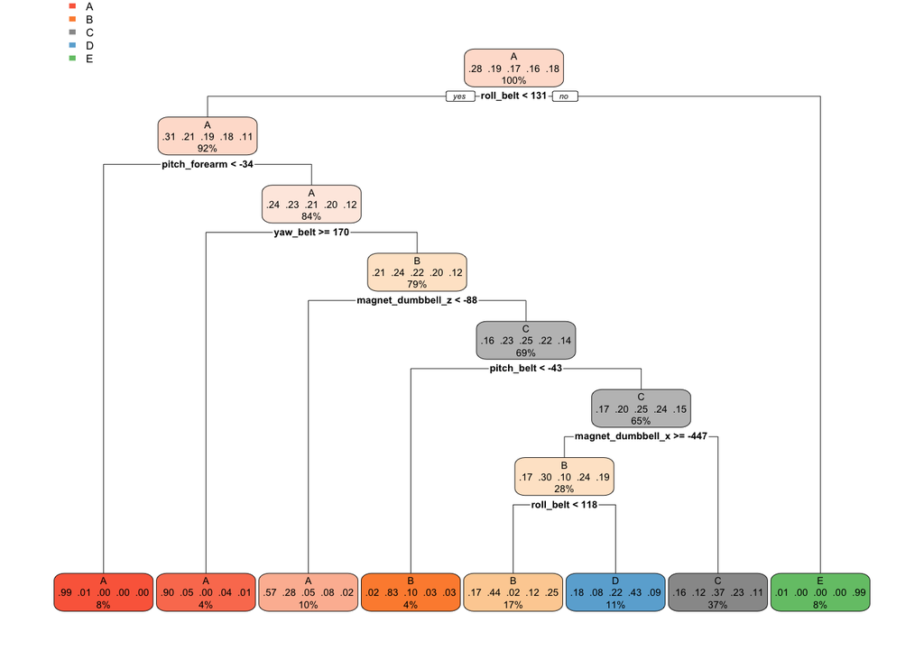

```r
rpart.plot(decisionTreeMod$finalModel)
```

## ML Algorithm - Random Forest

```r
rfMod <- train(classe ~., method='rf', data=training_training_data, ntree=128)
rfPrediction <- predict(rfMod, training_crossval_data)
confusionMatrix(training_crossval_data$classe, rfPrediction)
```

```
## Confusion Matrix and Statistics
##
##           Reference
## Prediction    A    B    C    D    E
##          A 1395    0    0    0    0
##          B    6  939    4    0    0
##          C    0    3  849    3    0
##          D    0    0   10  794    0
##          E    0    0    2    5  894
##
## Overall Statistics
##
##                Accuracy : 0.9933
##                  95% CI : (0.9906, 0.9954)
##     No Information Rate : 0.2857
##     P-Value [Acc > NIR] : < 2.2e-16
##
##                   Kappa : 0.9915
##  Mcnemar's Test P-Value : NA
##
## Statistics by Class:
##
##                      Class: A Class: B Class: C Class: D Class: E
## Sensitivity            0.9957   0.9968   0.9815   0.9900   1.0000
## Specificity            1.0000   0.9975   0.9985   0.9976   0.9983
## Pos Pred Value         1.0000   0.9895   0.9930   0.9876   0.9922
## Neg Pred Value         0.9983   0.9992   0.9960   0.9980   1.0000
## Prevalence             0.2857   0.1921   0.1764   0.1635   0.1823
## Detection Rate         0.2845   0.1915   0.1731   0.1619   0.1823
## Detection Prevalence   0.2845   0.1935   0.1743   0.1639   0.1837
## Balanced Accuracy      0.9979   0.9971   0.9900   0.9938   0.9991
```

## Predicting on Test Data Set

```r
predict(rfMod, clean_test_data)
```

```
##  [1] B A B A A E D B A A B C B A E E A B B B
## Levels: A B C D E
```

## Conclusion

So, the estimated accuracy of the model is 99.32% and the estimated out-of-sample error is 0.68%